# Practice Problems 8

Solutions

# Part 0. Load Packages

Use the code chunk below to load any packages that you need for this assignment. Add `message = FALSE` to the top of your code chunk to hide the messages that print out when you load these packages.

```r
# you should have loaded these packages:
library(readr)
library(dplyr)
library(ggplot2)
library(broom)
library(mosaic)

# depending on your project data, you may also have needed other packages
# e.g., library(NHANES)
```

> Make sure you added `message = FALSE` to the start of your code chunk.

# Part 1. Bikeshare Data

Answer the following questions about the `bikeshare.csv` dataset. *Hint: look at Activities 26 and 27.*

## Load Data in R

Enter code in the code chunk below to load the `bikeshare.csv` dataset into R. Make sure that you’ve downloaded the `.csv` file from Moodle and it’s saved in the same folder as this RMD. Add `message = FALSE` to the top of your code chunk to hide the messages that print out when you read in this data set.

```r
bikes.pop <- read_csv('../activities/bikeshare.csv')
```

> I have the `bikeshare.csv` dataset stored in a different folder than this RMD, so my code may look a little different from yours. If your CSV and RMD files are saved in the same folder, then the code will just be `bikes.pop <- read_csv('bikeshare.csv')`.

> Make sure you added `message = FALSE` to the start of your code chunk.

## Prepare Data

Let’s suppose that the two years of bike share data contained in `bikeshare.csv` is our population of interest. We’re going to simulate the process of sampling from this population by taking a random sample of 50 days from the two years of bike share data. Since sampling is random, we will all end up with slightly different samples. Add code to the code chunk below to get your sample.

```r
# sample from population
bikes.sample <- bikes.pop %>%
  sample_n(size = 50) ## take random sample of size 50 from bikes.pop
```

Use this smaller sample of 50 days for the rest of the assignment.

## Fit Linear Regression Model

Now, let’s consider our scientific question: is casual bike ridership lower on days that are windier? To answer this question, we might start by fitting the following simple linear regression model:

$$\widehat{CasualRiders} = \hat\beta_0 + \hat\beta_1 Windspeed$$

Add code to the code chunk below to fit this model to your **sample** data (not the entire population of two years) to answer this question. Don’t forget to save this model so we can use it again in later questions.

```r
# fit linear model
mod <- lm(riders_casual ~ windspeed, data = bikes.sample)
```

> Make sure you fit this model to your sample data (`bikes.sample`), not the population data (`bikes.pop`).

## Bootstrapping

Bootstrapping is a powerful tool for understanding and quantifying how much our estimates would vary from sample to sample. Rather than re-sampling from the population, we are going to re-sample **from our original sample**.

Add code to the code chunk below to re-sample from your dataset 500 times, fit the same linear regression model to each of those datasets, and record the coefficient estimates from each new sample. Then, make two histograms to visualize the bootstrap sampling distribution for the intercept and slope coefficients.

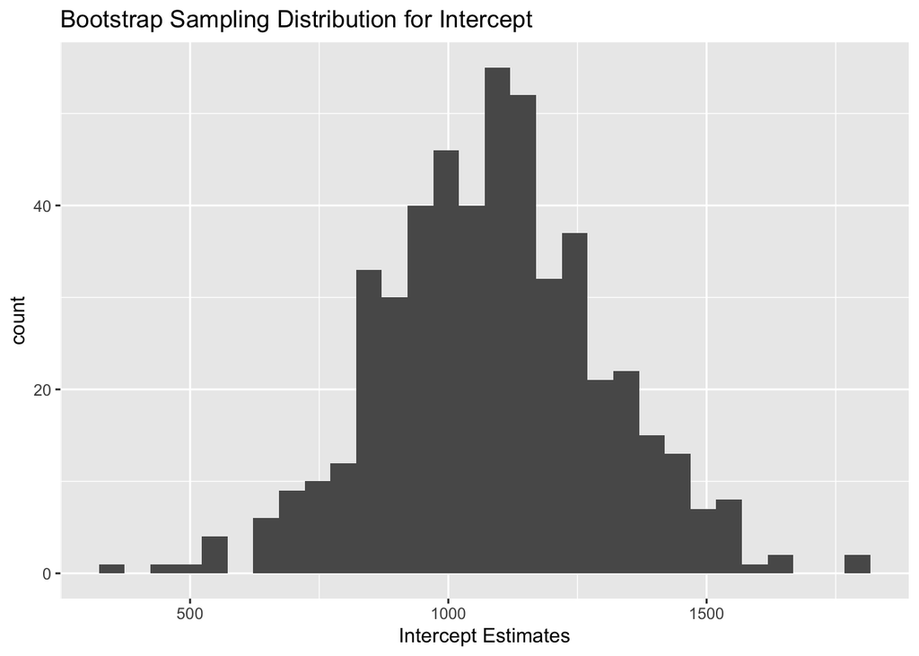

```r
# run bootstrapping
boot.data <- mosaic::do(500)*(
  bikes.sample %>%
    sample_frac(replace = TRUE) %>% # re-samples from sample with replacement
    with(lm(riders_casual ~ windspeed)) # fits your linear regression model on new sample
)

# make histogram for intercept
boot.data %>%
  ggplot(aes(x = Intercept)) +
  geom_histogram() +
  labs(x = 'Intercept Estimates', title = 'Bootstrap Sampling Distribution for Intercept')
```

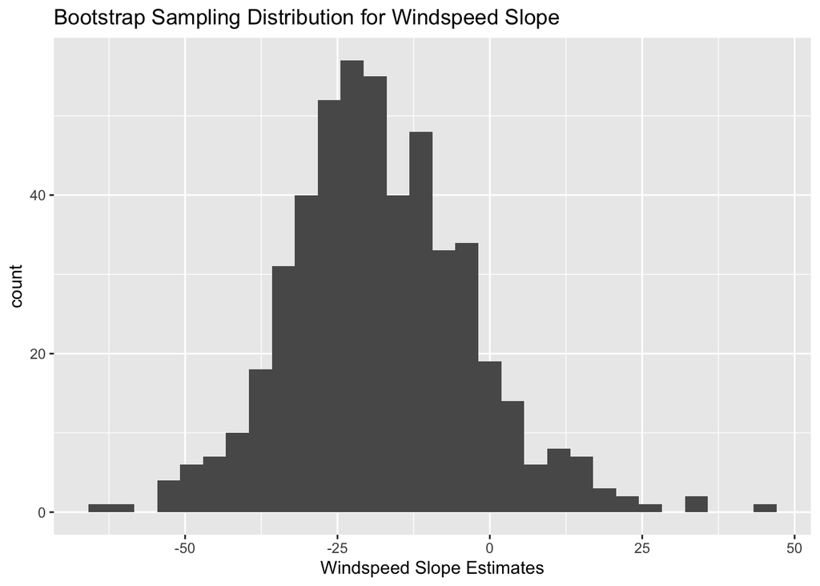

```r
# make histogram for slope
boot.data %>%
  ggplot(aes(x = windspeed)) +
  geom_histogram() +
  labs(x = 'Windspeed Slope Estimates', title = 'Bootstrap Sampling Distribution for Windspeed Slope')
```

Describe the bootstrap sampling distributions and what information they provide.

> The bootstrap sampling distribution is a distribution that attempts to mimic the sampling distribution we would see if we could actually re-sample from the population. The shape and spread of this distribution should be close to the sampling distribution from the population, but this distribution is centered at the original sample estimates, rather than the true population values. Although the bootstrap sampling distribution may not be centered at the true population value, it is still a very useful tool to help us gauge the *variability* in our estimates.

> In this case, we can see from our bootstrap sampling distributions that estimates of the intercept tend to range from about 500 riders to about 1500 riders, depending on the dataset, and estimates of the slope range from negative 50 riders per mph (number of riders decrease as windspeed increases) to positive 25 riders per mph (number of riders increase as windspeed increases). The fact that the bootstrap sampling distribution for the slope estimate crosses zero is important to notice here: depending on the dataset, we sometimes estimate that the number of riders decreases as windspeed increases (negative slope estimate), and in others we estimate the reverse (positive slope estimate). This indicates that we have some uncertainty about how, and even if, windspeed is related to ridership.

## Standard Error

We have discussed two different ways to calculate the standard error of a regression coefficient estimate. Add code to the code chunk below to implement those two approaches here. *Hint: one approach should involve your bootstrapping estimates from above; the other should involve a function that will perform the “classical”/theoretical approach for us.*

```r
# bootstrapping SE
boot.data %>%
  summarize(sd(Intercept), sd(windspeed))
```

```
##   sd(Intercept) sd(windspeed)
## 1      213.0378      15.02374
```

```r
# classical SE
tidy(mod)
```

```
## # A tibble: 2 × 5
##   term        estimate std.error statistic   p.value
##   <chr>          <dbl>     <dbl>     <dbl>     <dbl>
## 1 (Intercept)   1085.      232.       4.68 0.0000239
## 2 windspeed      -18.0      15.7     -1.15 0.257
```

Report the standard errors that you got for the `windspeed` coefficient from each approach. How similar are the two estimates?

> The bootstrapping standard error estimate is 15.02 and the classical standard error estimate is 15.71. These are quite similar (as we’d expect! this is just two different ways of estimating the same thing).

Then, discuss/interpret one of these standard error estimates. What information does the standard error provide?

> The standard error quantifies how much the slope estimates would vary from sample to sample. This helps communicate the uncertainty in our estimate.

## Confidence Interval

Now, construct 95% confidence intervals for the `Intercept` and `windspeed` coefficients using the two techniques we have discussed: bootstrapping and the classical/theoretical approach.

```r
# bootstrapping CI
boot.data %>%
  summarize(lb.int = quantile(Intercept, 0.025), ub.int = quantile(Intercept, 0.975),
            lb.wind = quantile(windspeed, 0.025), ub.wind = quantile(windspeed, 0.975))
```

```
##     lb.int   ub.int  lb.wind  ub.wind
## 1 673.9133 1520.098 -46.4404 13.98685
```

```r
# classical CI
confint(mod)
```

```
##                 2.5 %     97.5 %
## (Intercept) 618.83973 1551.70317
## windspeed   -49.59586   13.58391
```

Report the 95% confidence interval that you got for the `windspeed` coefficient from each approach. How similar are the two intervals?

> For the windspeed slope coefficient, I got a 95% confidence interval (-46.44, 13.99) from bootstrapping and an interval of (-49.60, 13.58) from the classical approach. These intervals are slightly different, but generally very similar (as expected!).

Then, write a full, accurate sentence interpreting one of these confidence intervals.

> For each additional 1 mile per hour increase in wind speed, we’d expect to see between a 46 rider decrease and a 14 rider increase in daily casual riders. We are unsure whether this interval contains the true population average change in casual ridership per 1mph increase in windspeed, but we trust that 95% of samples will have intervals that contain the true change.

> Note that our “confidence” is *in our interval construction process*: we expect that in 95% of all possible samples, the constructed confidence intervals will contain the true population parameter.

> Important things to remember in interpreting confidence intervals:
> - we must be careful not to suggest in our interpretation that there is a 95% *probability* that the true population parameter falls within this interval
> - the interval gives a range of plausible values for the *population parameter* (i.e., the true relationship between windspeed and ridership in the population), not the *sample statistic* (the estimated relationship between windspeed and ridership based on our datsaet)
> - if you use the phrasing “I am 95% confident that…”, it is helpful to clarify in your interpretation what you mean by “95% confident”

Does your confidence interval include zero? What does this tell us about the relationship between wind speed and ridership?

> My confidence interval does contain zero! Since this interval provides plausible values for the true slope, this suggests it is plausible there is no relationship between wind speed and average number of casual riders — we can’t rule out the possibility that there may not be a relationship between these variables. In other words, we do not have enough evidence to suggest, with certainty, that there *is* a true negative relationship between wind speed and average number of casual riders.

> If your interval does not contain zero, our conclusion is a bit different. If the interval doesn’t contain zero, then we *do* have enough evidence to suggest that there is a true negative relationship between wind speed and average number of casual riders

# Part 2. Project Data

Answer the following questions about your chosen project dataset. Use the same dataset you used last week (unless you have approval from Kelsey to change datasets).

## Load and Prepare Data

Use the code chunk provided below to read your chosen data set into R. Add `messsage = FALSE` to the start of your code chunk to hide the messages that print out when you read in this dataset.

> If you’re using the NHANES data for your project, your code should look something like this:

```r
# load package first, or put this up in Part 0
library(NHANES)

# then read in dataset
data(NHANES)
```

> Otherwise, you’re likely using the `read_csv` function to read in your data from a CSV file. Since we already loaded the `readr` package in an earlier code chunk, we don’t need to do it again here:

```r
# read in dataset
project <- read_csv('projectdata.csv')
```

> Note: in the example above, my code reads in a dataset called “projectdata.csv” and saves it as an object called `project`. You can give your data whatever* name you like! Just make sure to use the same name throughout. For example, if you named your data `kiva` (`kiva <- read_csv('...')`) then run the `ggplot` function on “kiva” as well (`kiva %>% ggplot(...)` in the next question).

> *there are a few rules to naming objects in R. Names can’t start with a number, can’t include some special characters like @, /, &, or spaces, and shouldn’t be the name of something that already exists (e.g., don’t name your data “read_csv”). I recommend using a name that’s short and informative, so it’s easy to type and easy to remember what you called it.

> Another note: the `read_csv()` function prints out quite a bit of information when it loads in the dataset. You can hide these messages by adding `message = FALSE` to the first line of your code chunk. It should like something like this: `{r name-of-chunk, message = FALSE}`.

Use the next code chunk to perform any data cleaning or other preparation that you need (e.g., filtering missing values, creating or modifying variables) to fit your regression models, below.

> Here are two examples of what the code might look like to create a new variable (using `mutate`) or filter out outliers or missing values. Your steps here, of course, will be unique to your dataset and research question. Stop by office hours for help with brainstorming and implementing any data cleaning steps that are necessary for your project.

```r
## example: make categorical variable from a quantitative one
## for more examples, see Crowd-Sourced R Help File on Moodle
data <- data %>%
  mutate(Xcat = cut(Xquant, 4), # cut quantitative into 4 categories
         Xbinary = ifelse(Xquant > 25, 1, 0)) # create binary (1/0) variable indicating if quant was greater than 25

## example: filter cases
data.filtered <- data %>%
  filter(Y <= 100)  %>% # keep y values less than or equal to 100
  filter(!is.na(x))  # keep cases that are not missing (NA) for variable x
```

## Research Questions

Remind us what your two research questions are:

> Research Question #1 (quantitative outcome): to meet expectations, your response should describe a research question involving a quantitative outcome and one or two explanatory variables

> Research Question #2 (binary outcome): to meet expectations, your response should describe a research question involving a binary outcome and one or two explanatory variables

## Fit Models

Fit the models that you will be using to address your research questions in the code chunk belows. Don’t forget to save these models so you can use them again in the next question.

```r
# fit model 1
mod.linear <- data.linear.filtered %>%
  with(lm(y ~ x1 + x2))
```

```r
# fit model 2
mod.logistic <- data.logistic.filtered %>%
  with(glm(outcome ~ x1 + x2, family = binomial)) # don't forget family = binomial!
```

## Confidence Intervals

Calculate 95% confidence intervals for the coefficients in your regression models using the classical/theoretical approach.

```r
# confidence interval for linear regression
confint(mod.linear)
```

```r
# confidence interval for logistic regression
confint(mod.logistic) %>%
  exp() # don't forget to exponentiate!
```

Using full, good sentences, write a sentence that interprets the confidence interval for the coefficient(s) of interest from each of your models. (You do not need to, and should not, write out interpretations for *every* confidence interval in these two models—just focus on the one(s) that are most relevant to your research question.) Double-check the [Final Grading Rubric](https://docs.google.com/spreadsheets/d/14PFacGUuS5tiQuTdpbL155L8YTQLWnXg9Tb9qt-vYVg/edit#gid=0) to make sure you are meeting all expectations for confidence interval interpretations.

> There are a few different ways to interpret a 95% confidence interval for a coefficient from a **linear regression** model:
> - Example 1: we are 95% confident that the population parameter (i.e., the true difference in average Y associated with a 1 unit change in X1, holding X2 constant) is between lb and ub.
> - Example 2: based on our 95% confidence interval, our data would not be judged unusual if the population parameter (i.e., the true difference in average Y associated with a 1 unit change in X1, holding X2 constant) were between lb and ub.
> - Example 3: The true population average change in Y per unit change in X1, holding X2 constant could be between lb and ub. While we are unsure if our 95% confidence interval contains the true population value, we are confident in our interval construction process in that 95% of samples from the broader population are expected to contain the truth.

> In a second sentence, you should comment on **whether your confidence interval contains zero**, and what this implies.
> - If your interval contains zero, it is plausible that there is no association between X1 and Y after adjusting for X2.
> - If your interval does not contain zero, we have evidence to suggest that there *is* an association between X1 and Y after adjusting for X2.

> There are a few different ways to interpret a 95% confidence interval for an *exponentiated* slope coefficient from a **logistic regression** model:
> - Example 1: we are 95% confident that the population parameter (i.e., the true multiplicative increase in odds that Y = 1 associated with a 1 unit change in X1, holding X2 constant) is between lb and ub.
> - Example 2: based on our 95% confidence interval, our data would not be judged unusual if the population parameter (i.e., the true multiplicative increase in odds that Y = 1 associated with a 1 unit change in X1, holding X2 constant) were between lb and ub.
> - Example 3: The true population multiplicative change in odds that Y = 1 associated with a 1 unit change in X1, holding X2 constant could be between lb and ub. While we are unsure if our 95% confidence interval contains the true population value, we are confident in our interval construction process in that 95% of samples from the broader population are expected to contain the truth.

> In a second sentence, you should comment on **whether your confidence interval contains one**, and what this implies.
> - If your interval contains one, it is plausible that there is no association between X1 and Y after adjusting for X2.
> - If your interval does not contain one, we have evidence to suggest that there *is* an association between X1 and Y after adjusting for X2.

> Your interpretations must make clear that the confidence interval provides a range of plausible values for the *population parameter* (not the sample estimate), and your interpretation must NOT imply that there is a 95% *probability* the parameter is in the interval. It is most helpful if your interpretation provides context about what the population parameter represents (i.e., the true slope in the population, writing out a full interpretation of what that slope represents). It is also helfpul to add a sentence clarifying what it is that you are “confident” in: the interval construction **procedure**.

# Part 3. Knit

Once you’ve answered all the questions above, you’ll need to `Knit` this document and then save that knitted document as a PDF. See the assignment *Instructions* at the top of this document and on Moodle for more details.